# Problem 1:

Consider Jupyter notebook Classifying-movie-reviews.ipynb we discussed in class. Run provided notebook, if anything needs fixing, please fix. Stick to RMSPROP optimizer. (10%)

# Classifying movie reviews. A binary classification

This notebook contains code from the book Deep Learning with Python by Francois Chollet Chapter 3.

```python
import keras
```

In this example, we will learn to classify movie reviews into "positive" reviews and "negative" reviews, just based on the text content of the reviews.

Test set has already been preprocessed: the reviews (sequences of words) have been turned into sequences of integers, where each integer stands for a specific word in a dictionary.

```python
from keras.datasets import imdb

(train_data, train_labels), (test_data, test_labels) = imdb.load_data(num_words=10000)
```

The argument `num_words=10000` means that we will only keep the top 10,000 most frequently occurring words in the training data. Rare words will be discarded. This allows us to work with vector data of manageable size.

The variables `train_data` and `test_data` are lists of reviews, each review being a list of word indices (encoding a sequence of words). `train_labels` and `test_labels` are lists of 0s and 1s, where 0 stands for "negative" and 1 stands for "positive":

```python
print("train_data:", type(train_data), train_data.shape)
print("train_labels:", type(train_labels), train_labels.shape)
print("test_data:", type(test_data), test_data.shape)
print("test_labels:", type(test_labels), test_labels.shape)
```

```
train_data: <class 'numpy.ndarray'> (25000,)
train_labels: <class 'numpy.ndarray'> (25000,)
test_data: <class 'numpy.ndarray'> (25000,)
test_labels: <class 'numpy.ndarray'> (25000,)
```

```python
print(type(train_data[1]), len(train_data[1]))
print(type(train_data[2]), len(train_data[2]))
print(type(train_data[3]), len(train_data[3]))
print(type(train_data[24001]), len(train_data[24001]))
```

```
<class 'list'> 189
<class 'list'> 141
<class 'list'> 550
<class 'list'> 158
```

```python
print(type(train_data))
print(type(train_data[6]))
```

```
<class 'numpy.ndarray'>
<class 'list'>
```

```python
train_data[6]
```

```
[1,
 6740,
 365,
 1234,
 5,
 1156,
 354,
 11,
 14,
 5327,
 6638,
 7,
 1016,
 2,
 5940,
 356,
 44,
 4,
 1349,
 500,
 746,
 5,
 200,
 4,
 4132,
 11,
 2,
 9363,
 1117,
 1831,
 7485,
 5,
 4831,
 26,
 6,
 2,
 4183,
 17,
 369,
 37,
```

[output cut: 68 more lines]

```
 419,
 665,
 40,
 91,
 85,
 108,
 7,
 4,
 2084,
 5,
 4773,
 81,
 55,
 52,
 1901]
```

We will refer to every small text representing a movie review as a sequnce. Sequences are made of numbers representing different words. Since we restricted ourselves to the top 10,000 most frequent words, no word index will exceed 10,000:

```python
max([max(sequence) for sequence in train_data])
```

```
9999
```

You can quickly decode one of these reviews back to English words:

```python
# word_index is a dictionary mapping words to an integer index
word_index = imdb.get_word_index()
print(type(word_index), len(word_index))
# print(word_index.keys())
i = 0
for item in word_index.items():
    print(item)
    i = i + 1
    if(i > 4):
        break
```

```
<class 'dict'> 88584
('fawn', 34701)
('tsukino', 52006)
('nunnery', 52007)
('sonja', 16816)
('vani', 63951)
```

```python
# We reverse word_index, mapping integer indices to words
reverse_word_index = {value: key for key, value in word_index.items()}
i = 0
for item in reverse_word_index.items():
    print(i,":",item)
    i = i + 1
    if(i > 4):
        break
```

```
0 : (34701, 'fawn')
1 : (52006, 'tsukino')
2 : (52007, 'nunnery')
3 : (16816, 'sonja')
4 : (63951, 'vani')
```

```python
train_data[6]
```

```
[1,
 6740,
 365,
 1234,
 5,
 1156,
 354,
 11,
 14,
 5327,
 6638,
 7,
 1016,
 2,
 5940,
 356,
 44,
 4,
 1349,
 500,
 746,
 5,
 200,
 4,
 4132,
 11,
 2,
 9363,
 1117,
 1831,
 7485,
 5,
 4831,
 26,
 6,
 2,
 4183,
 17,
 369,
 37,
```

[output cut: 68 more lines]

```
 419,
 665,
 40,
 91,
 85,
 108,
 7,
 4,
 2084,
 5,
 4773,
 81,
 55,
 52,
 1901]
```

```python
# We decode the reviews
# Please note when word_index was crated the indices were offset by 3
# because indeces: 0, 1 and 2 were reserved indices for "padding", "start of sequence", and "unknown".
# The third review, index 2, now reads in Eglish
decoded_review = ' '.join([reverse_word_index.get(i - 3, '?') for i in train_data[6]])
```

```python
decoded_review
```

```
"? lavish production values and solid performances in this straightforward adaption of jane ? satirical classic about the marriage game within and between the classes in ? 18th century england northam and paltrow are a ? mixture as friends who must pass through ? and lies to discover that they love …
```

```python
# print(word_index['padding'], word_index['unknown'])
print(reverse_word_index.get(-2))
print(reverse_word_index.get(6737))
print(reverse_word_index.get(362))
```

```
None
lavish
production
```

```python
# If you doubt the advice about shifting keys by 3, try without the shift:
decoded_review = ' '.join([reverse_word_index.get(i, '?') for i in train_data[6]])
```

```python
decoded_review
```

```
"the boiled full involving to impressive boring this as murdering naschy br villain and suggestion need has of costumes b message to may of props this and concentrates concept issue skeptical to god's he is and unfolds movie women like isn't surely i'm and to toward in here's for from did having bec…
```

## Preparing the data

We cannot feed `train_data` and `test_data`, which are the lists of integers, into a neural network. We have to turn our lists into tensors.

- We could pad our lists so that they all have the same length, and turn them into an integer tensor of shape `(samples, word_indices)`.
- We could one-hot-encode our lists to turn them into vectors of 0s and 1s. Concretely, this would mean for instance turning the sequence `[3, 5]` into a 10,000-dimensional vector that would be all-zeros except for indices 3 and 5, which would be ones. Then, as the first layer in our network we could use a `Dense` layer, capable of handling floating point vector data.

Let's vectorize our data, preparing one-hot-encoded vectors.

```python
import numpy as np

def vectorize_sequences(sequences, dimension=10000):
    # Create an all-zero matrix of shape (len(sequences), dimension)
    results = np.zeros((len(sequences), dimension))
    for i, sequence in enumerate(sequences):
        # e.g. we are placing label 1.0 in position 389,
        # if a word with has value 389 in word_index dictorionary.
        # this is a bag of words model. We will come back to this later in the course
        results[i, sequence] = 1.  # set specific indices of results[i] to 1s

    return results

# Our vectorized training data
x_train = vectorize_sequences(train_data)
print("shape of x_train: ", x_train.shape)
# Our vectorized test data
x_test = vectorize_sequences(test_data)
print("shape of x_test: ", x_test.shape)

# data = [[3], [2,3]]
# d_train = vectorize_sequences(data, 4)
# d_train
# shape should be (2, 4)
```

```
shape of x_train:  (25000, 10000)
shape of x_test:  (25000, 10000)
```

Here's what our samples look like now:

```python
x_train.shape
```

```
(25000, 10000)
```

```python
print("len x[0]:", len(x_train[0]),"\n", x_train[0])
print("len x[10000]:", len(x_train[10000]),"\n", x_train[0])
```

```
len x[0]: 10000
 [0. 1. 1. ... 0. 0. 0.]
len x[10000]: 10000
 [0. 1. 1. ... 0. 0. 0.]
```

```python
# The following illustrates how we assigned number 1 to every element
# of a row that corresponds to a word index in x_train.
illustration = np.zeros((3,5))
print(illustration)
sentences=[[0,4],[2,3],[4,3,4]]
for i in range(0,3):
    illustration[i,sentences[i]] = 1.0

print("\n",illustration)
```

```
[[0. 0. 0. 0. 0.]
 [0. 0. 0. 0. 0.]
 [0. 0. 0. 0. 0.]]

 [[1. 0. 0. 0. 1.]
 [0. 0. 1. 1. 0.]
 [0. 0. 0. 1. 1.]]
```

We should also vectorize our labels, which is straightforward:

```python
# Our vectorized labels
import numpy as np
y_train = np.asarray(train_labels).astype('float32')
y_test = np.asarray(test_labels).astype('float32')
```

```python
print(y_train[0:8])
```

```
[1. 0. 0. 1. 0. 0. 1. 0.]
```

Now our data is ready to be fed into a neural network.

## Building our network

Our input data is simply vectors, and our labels are scalars (1s and 0s). A type of network that performs well on such a problem would be a simple stack of fully-connected (`Dense`) layers with `relu` activations: `Dense(16, activation='relu')`

Each such `Dense` layer with a `relu` activation implements the following chain of tensor operations:

`output = relu(dot(W, input) + b)`

Having 16 hidden units means that the weight matrix `W` will have shape `(input_dimension, 16)`, i.e. the dot product with `W` will project the input data onto a 16-dimensional representation space (and then we would add the bias vector `b` and apply the `relu` operation). In our case the `input` dimension is 10,000. There are 25,000 samples of dimension 10,000 each.

There are two key architecture decisions to make about such stack of dense layers:

- How many layers to use.
- How many "hidden units" to chose for each layer.

Sigmoid "squashes" arbitrary values into the `[0, 1]` interval, thus outputting something that can be interpreted as a probability.

### Keras implementation:

```python
from tensorflow.keras import models
from tensorflow.keras import layers, Input

model = models.Sequential()
model.add(Input(shape=(10000,))),
model.add(layers.Dense(16, activation='relu'))
model.add(layers.Dense(16, activation='relu'))
model.add(layers.Dense(1, activation='sigmoid'))
```

We need to pick a loss function and an optimizer. Since we are facing a binary classification problem and the output of our network is a probability (we end our network with a single-unit layer with a sigmoid activation), is it best to use the `binary_crossentropy` loss. It isn't the only viable choice: you could use, for instance, `mean_squared_error`. But crossentropy is usually the best choice when you are dealing with models that output probabilities.

Here's the step where we configure our model with the `rmsprop` optimizer and the `binary_crossentropy` loss function. Note that we will also monitor accuracy during training.

```python
model.compile(optimizer='rmsprop',   # 'adam' is a popular alternative
              loss='binary_crossentropy',
              metrics=['accuracy'])
```

We are passing our optimizer, loss function and metrics as strings, which is possible because `rmsprop`, `binary_crossentropy` and `accuracy` are packaged as part of Keras. Sometimes you may want to configure the parameters of your optimizer, or pass a custom loss function or metric function. This former can be done by passing an optimizer class instance as the `optimizer` argument:

```python
from tensorflow.keras import optimizers

model.compile(optimizer=optimizers.RMSprop(learning_rate=0.001),
              loss='binary_crossentropy',
              metrics=['accuracy'])
```

The latter can be done by passing function objects as the `loss` or `metrics` arguments:

```python
from tensorflow.keras import losses
from tensorflow.keras import metrics

model.compile(optimizer=optimizers.RMSprop(learning_rate=0.001),
              loss=losses.binary_crossentropy,
              metrics=[metrics.binary_accuracy])
```

## Validating our approach

In order to verify the accuracy of the model on data that it has never seen before, we will create a "validation set" by setting apart 10,000 samples from the original training data:

```python
x_val = x_train[:10000]
partial_x_train = x_train[10000:]

y_val = y_train[:10000]
partial_y_train = y_train[10000:]
```

We will now train our model for 20 epochs (20 iterations over all samples in the `x_train` and `y_train` tensors), in mini-batches of 512 samples. At this same time we will monitor loss and accuracy on the 10,000 samples that we set apart. This is done by passing the validation data as the `validation_data` argument:

```python
history = model.fit(partial_x_train,
                    partial_y_train,
                    epochs=20,
                    batch_size=512,
                    validation_data=(x_val, y_val))
```

```
30/30 ━━━━━━━━━━━━━━━━━━━━ 1s 16ms/step - binary_accuracy: 0.7631 - loss: 0.5413 - val_binary_accuracy: 0.8622 - val_loss: 0.4081
30/30 ━━━━━━━━━━━━━━━━━━━━ 0s 4ms/step - binary_accuracy: 0.8918 - loss: 0.3347 - val_binary_accuracy: 0.8745 - val_loss: 0.3252
30/30 ━━━━━━━━━━━━━━━━━━━━ 0s 4ms/step - binary_accuracy: 0.9167 - loss: 0.2498 - val_binary_accuracy: 0.8848 - val_loss: 0.2895
30/30 ━━━━━━━━━━━━━━━━━━━━ 0s 4ms/step - binary_accuracy: 0.9326 - loss: 0.2013 - val_binary_accuracy: 0.8878 - val_loss: 0.2751
30/30 ━━━━━━━━━━━━━━━━━━━━ 0s 4ms/step - binary_accuracy: 0.9450 - loss: 0.1698 - val_binary_accuracy: 0.8839 - val_loss: 0.2825
30/30 ━━━━━━━━━━━━━━━━━━━━ 0s 4ms/step - binary_accuracy: 0.9523 - loss: 0.1444 - val_binary_accuracy: 0.8861 - val_loss: 0.2809
30/30 ━━━━━━━━━━━━━━━━━━━━ 0s 4ms/step - binary_accuracy: 0.9629 - loss: 0.1213 - val_binary_accuracy: 0.8845 - val_loss: 0.2920
30/30 ━━━━━━━━━━━━━━━━━━━━ 0s 4ms/step - binary_accuracy: 0.9668 - loss: 0.1057 - val_binary_accuracy: 0.8834 - val_loss: 0.3048
30/30 ━━━━━━━━━━━━━━━━━━━━ 0s 4ms/step - binary_accuracy: 0.9716 - loss: 0.0938 - val_binary_accuracy: 0.8641 - val_loss: 0.3765
30/30 ━━━━━━━━━━━━━━━━━━━━ 0s 4ms/step - binary_accuracy: 0.9793 - loss: 0.0789 - val_binary_accuracy: 0.8790 - val_loss: 0.3355
30/30 ━━━━━━━━━━━━━━━━━━━━ 0s 4ms/step - binary_accuracy: 0.9811 - loss: 0.0674 - val_binary_accuracy: 0.8779 - val_loss: 0.3651
30/30 ━━━━━━━━━━━━━━━━━━━━ 0s 4ms/step - binary_accuracy: 0.9861 - loss: 0.0580 - val_binary_accuracy: 0.8775 - val_loss: 0.3861
30/30 ━━━━━━━━━━━━━━━━━━━━ 0s 5ms/step - binary_accuracy: 0.9880 - loss: 0.0507 - val_binary_accuracy: 0.8766 - val_loss: 0.4057
30/30 ━━━━━━━━━━━━━━━━━━━━ 0s 4ms/step - binary_accuracy: 0.9915 - loss: 0.0407 - val_binary_accuracy: 0.8706 - val_loss: 0.4284
30/30 ━━━━━━━━━━━━━━━━━━━━ 0s 4ms/step - binary_accuracy: 0.9945 - loss: 0.0336 - val_binary_accuracy: 0.8746 - val_loss: 0.4393
30/30 ━━━━━━━━━━━━━━━━━━━━ 0s 4ms/step - binary_accuracy: 0.9951 - loss: 0.0290 - val_binary_accuracy: 0.8749 - val_loss: 0.4628
30/30 ━━━━━━━━━━━━━━━━━━━━ 0s 4ms/step - binary_accuracy: 0.9961 - loss: 0.0240 - val_binary_accuracy: 0.8733 - val_loss: 0.5019
30/30 ━━━━━━━━━━━━━━━━━━━━ 0s 4ms/step - binary_accuracy: 0.9965 - loss: 0.0222 - val_binary_accuracy: 0.8645 - val_loss: 0.5365
30/30 ━━━━━━━━━━━━━━━━━━━━ 0s 4ms/step - binary_accuracy: 0.9993 - loss: 0.0145 - val_binary_accuracy: 0.8700 - val_loss: 0.5626
30/30 ━━━━━━━━━━━━━━━━━━━━ 0s 4ms/step - binary_accuracy: 0.9967 - loss: 0.0169 - val_binary_accuracy: 0.8679 - val_loss: 0.5654
```

On CPU, this will take less than two seconds per epoch -- training is over in 20 seconds. At the end of every epoch, there is a slight pause as the model computes its loss and accuracy on the 10,000 samples of the validation data.

Note that the call to `model.fit()` returns a `History` object. This object has a member `history`, which is a dictionary containing data about everything that happened during training. Let's take a look at it:

```python
history_dict = history.history
history_dict.keys()
```

```
dict_keys(['binary_accuracy', 'loss', 'val_binary_accuracy', 'val_loss'])
```

It contains 4 entries: one per metric that was being monitored, during training and during validation. Let's use Matplotlib to plot the training and validation loss side by side, as well as the training and validation accuracy:

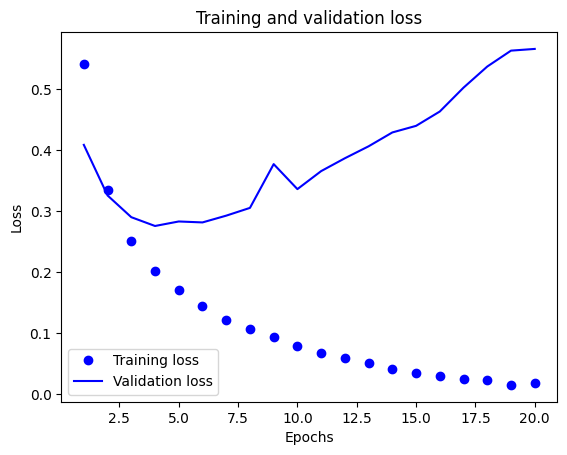

```python
import matplotlib.pyplot as plt

loss = history.history['loss']
val_loss = history.history['val_loss']

epochs = range(1, len(loss) + 1)

# "bo" is for "blue dot"
plt.plot(epochs, loss, 'bo', label='Training loss')
# b is for "solid blue line"
plt.plot(epochs, val_loss, 'b', label='Validation loss')
plt.title('Training and validation loss')
plt.xlabel('Epochs')
plt.ylabel('Loss')
plt.legend()

plt.show()
```

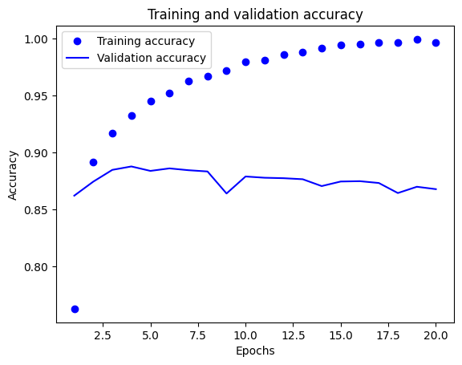

```python
import matplotlib.pyplot as plt

acc = history.history['binary_accuracy']
val_acc = history.history['val_binary_accuracy']

epochs = range(1, len(loss) + 1)

# "bo" is for "blue dot"
plt.plot(epochs, acc, 'bo', label='Training accuracy')
# b is for "solid blue line"
plt.plot(epochs, val_acc, 'b', label='Validation accuracy')
plt.title('Training and validation accuracy')
plt.xlabel('Epochs')
plt.ylabel('Accuracy')
plt.legend()

plt.show()
```

The dots are the training loss and accuracy, while the solid lines are the validation loss and accuracy.

In this case, to prevent overfitting, we could simply stop training after three epochs. In general, there is a range of techniques you can leverage to mitigate overfitting, which we will cover in the next chapter.

Let's train a new network from scratch for four epochs, then evaluate it on our test data:

```python
model = models.Sequential()
model.add(Input(shape=(10000,))),
model.add(layers.Dense(16, activation='relu'))
model.add(layers.Dense(16, activation='relu'))
model.add(layers.Dense(1, activation='sigmoid'))

model.compile(optimizer='rmsprop',
              loss='binary_crossentropy',
              metrics=['accuracy'])

model.fit(x_train, y_train, epochs=4, batch_size=512)
results = model.evaluate(x_test, y_test)
```

```
49/49 ━━━━━━━━━━━━━━━━━━━━ 0s 3ms/step - accuracy: 0.8113 - loss: 0.4872
49/49 ━━━━━━━━━━━━━━━━━━━━ 0s 3ms/step - accuracy: 0.8977 - loss: 0.2934
49/49 ━━━━━━━━━━━━━━━━━━━━ 0s 3ms/step - accuracy: 0.9196 - loss: 0.2278
49/49 ━━━━━━━━━━━━━━━━━━━━ 0s 3ms/step - accuracy: 0.9301 - loss: 0.1951
782/782 ━━━━━━━━━━━━━━━━━━━━ 0s 354us/step - accuracy: 0.8846 - loss: 0.2885
```

```python
results
```

```
[0.28845569491386414, 0.8845599889755249]
```

## Using a trained network to generate predictions on new data

After having trained a network, you will want to use it in a practical setting. You can generate the likelihood of reviews being positive by using the `predict` method:

```python
model.predict(x_test)
```

```
782/782 ━━━━━━━━━━━━━━━━━━━━ 0s 288us/step
```

```
array([[0.25019553],
       [0.99952453],
       [0.9123791 ],
       ...,
       [0.15212876],
       [0.14129704],
       [0.6240278 ]], shape=(25000, 1), dtype=float32)
```

As you can see, the network is very confident for some samples (0.99 or more, or 0.01 or less) but less confident for others (0.6, 0.4).

## Conclusions

Here's what you should take away from this example:

- There's usually quite a bit of preprocessing you need to do on your raw data in order to be able to feed it -- as tensors -- into a neural network. In the case of sequences of words, they can be encoded as binary vectors -- but there are other encoding options too.
- Stacks of `Dense` layers with `relu` activations can solve a wide range of problems (including sentiment classification), and you will likely use them frequently.
- In a binary classification problem (two output classes), your network should end with a `Dense` layer with 1 unit and a `sigmoid` activation, i.e. the output of your network should be a scalar between 0 and 1, encoding a probability.
- With such a scalar sigmoid output, on a binary classification problem, the loss function you should use is `binary_crossentropy`.
- The `rmsprop` optimizer is generally a good enough choice of optimizer, whatever your problem. That's one less thing for you to worry about.
- As they get better on their training data, neural networks eventually start *overfitting* and end up obtaining increasingly worse results on data never-seen-before. Make sure to always monitor performance on data that is outside of the training set.

# Problem 2 - Regularization

Above model is overfitting early. Please add L2 and L1 regularizations to the first and the second dense hidden layer. Run the model initially with just L1=0.001, next with just L2=0.001 then following pairs of L1, L2 parameters together: (0.01,0.01), (0.005,0.005). Apply the same regularization parameters to both Dense (16) layers in all cases. In all, you will perform 4 experiments. Compare accuracy and loss function plots with those you generated in Problem 1. Report whether applied regularizations affected the overfitting and if yes in what way.  
(20%)

##### Experiment 1: Add L1(0.001) Regularization to the Dense Layers

```python
from tensorflow.keras import regularizers

model = models.Sequential()
model.add(Input(shape=(10000,))),
model.add(layers.Dense(16, activation='relu', kernel_regularizer=regularizers.l1(0.001)))
model.add(layers.Dense(16, activation='relu', kernel_regularizer=regularizers.l1(0.001)))
model.add(layers.Dense(1, activation='sigmoid'))

model.compile(optimizer='rmsprop',
              loss='binary_crossentropy',
              metrics=['accuracy'])

history = model.fit(partial_x_train,
                    partial_y_train,
                    epochs=20,
                    batch_size=512,
                    validation_data=(x_val, y_val))
results = model.evaluate(x_test, y_test)
```

```
30/30 ━━━━━━━━━━━━━━━━━━━━ 1s 9ms/step - accuracy: 0.7291 - loss: 1.1511 - val_accuracy: 0.8000 - val_loss: 0.7373
30/30 ━━━━━━━━━━━━━━━━━━━━ 0s 5ms/step - accuracy: 0.8278 - loss: 0.6858 - val_accuracy: 0.8487 - val_loss: 0.6580
30/30 ━━━━━━━━━━━━━━━━━━━━ 0s 5ms/step - accuracy: 0.8531 - loss: 0.6220 - val_accuracy: 0.8508 - val_loss: 0.6177
30/30 ━━━━━━━━━━━━━━━━━━━━ 0s 5ms/step - accuracy: 0.8575 - loss: 0.5889 - val_accuracy: 0.8558 - val_loss: 0.5879
30/30 ━━━━━━━━━━━━━━━━━━━━ 0s 5ms/step - accuracy: 0.8611 - loss: 0.5690 - val_accuracy: 0.8567 - val_loss: 0.5776
30/30 ━━━━━━━━━━━━━━━━━━━━ 0s 5ms/step - accuracy: 0.8654 - loss: 0.5503 - val_accuracy: 0.8632 - val_loss: 0.5583
30/30 ━━━━━━━━━━━━━━━━━━━━ 0s 5ms/step - accuracy: 0.8659 - loss: 0.5429 - val_accuracy: 0.8469 - val_loss: 0.5799
30/30 ━━━━━━━━━━━━━━━━━━━━ 0s 5ms/step - accuracy: 0.8712 - loss: 0.5290 - val_accuracy: 0.8589 - val_loss: 0.5559
30/30 ━━━━━━━━━━━━━━━━━━━━ 0s 5ms/step - accuracy: 0.8681 - loss: 0.5312 - val_accuracy: 0.8597 - val_loss: 0.5509
30/30 ━━━━━━━━━━━━━━━━━━━━ 0s 5ms/step - accuracy: 0.8740 - loss: 0.5174 - val_accuracy: 0.8675 - val_loss: 0.5388
30/30 ━━━━━━━━━━━━━━━━━━━━ 0s 5ms/step - accuracy: 0.8738 - loss: 0.5148 - val_accuracy: 0.8519 - val_loss: 0.5604
30/30 ━━━━━━━━━━━━━━━━━━━━ 0s 5ms/step - accuracy: 0.8769 - loss: 0.5084 - val_accuracy: 0.8696 - val_loss: 0.5300
30/30 ━━━━━━━━━━━━━━━━━━━━ 0s 5ms/step - accuracy: 0.8758 - loss: 0.5049 - val_accuracy: 0.8724 - val_loss: 0.5235
30/30 ━━━━━━━━━━━━━━━━━━━━ 0s 5ms/step - accuracy: 0.8747 - loss: 0.5046 - val_accuracy: 0.8722 - val_loss: 0.5223
30/30 ━━━━━━━━━━━━━━━━━━━━ 0s 5ms/step - accuracy: 0.8799 - loss: 0.4973 - val_accuracy: 0.8603 - val_loss: 0.5410
30/30 ━━━━━━━━━━━━━━━━━━━━ 0s 5ms/step - accuracy: 0.8812 - loss: 0.4937 - val_accuracy: 0.8545 - val_loss: 0.5481
30/30 ━━━━━━━━━━━━━━━━━━━━ 0s 5ms/step - accuracy: 0.8791 - loss: 0.4954 - val_accuracy: 0.8532 - val_loss: 0.5489
30/30 ━━━━━━━━━━━━━━━━━━━━ 0s 5ms/step - accuracy: 0.8817 - loss: 0.4899 - val_accuracy: 0.8727 - val_loss: 0.5140
30/30 ━━━━━━━━━━━━━━━━━━━━ 0s 5ms/step - accuracy: 0.8847 - loss: 0.4861 - val_accuracy: 0.8754 - val_loss: 0.5100
30/30 ━━━━━━━━━━━━━━━━━━━━ 0s 5ms/step - accuracy: 0.8853 - loss: 0.4841 - val_accuracy: 0.8726 - val_loss: 0.5115
782/782 ━━━━━━━━━━━━━━━━━━━━ 0s 418us/step - accuracy: 0.8696 - loss: 0.5140
```

```python
history_dict = history.history
history_dict.keys()
```

```
dict_keys(['accuracy', 'loss', 'val_accuracy', 'val_loss'])
```

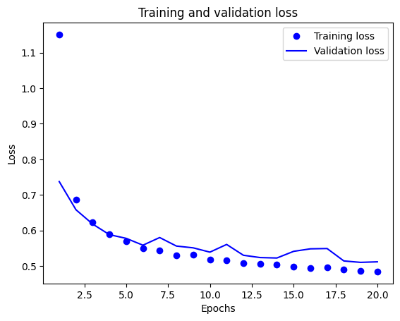

```python
loss = history.history['loss']
val_loss = history.history['val_loss']

epochs = range(1, len(loss) + 1)

# "bo" is for "blue dot"
plt.plot(epochs, loss, 'bo', label='Training loss')
# b is for "solid blue line"
plt.plot(epochs, val_loss, 'b', label='Validation loss')
plt.title('Training and validation loss')
plt.xlabel('Epochs')
plt.ylabel('Loss')
plt.legend()

plt.show()
```

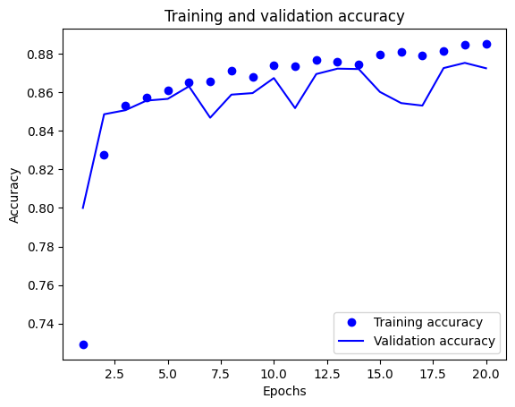

```python
acc = history.history['accuracy']
val_acc = history.history['val_accuracy']

epochs = range(1, len(loss) + 1)

# "bo" is for "blue dot"
plt.plot(epochs, acc, 'bo', label='Training accuracy')
# b is for "solid blue line"
plt.plot(epochs, val_acc, 'b', label='Validation accuracy')
plt.title('Training and validation accuracy')
plt.xlabel('Epochs')
plt.ylabel('Accuracy')
plt.legend()

plt.show()
```

```python
results
```

```
[0.5139966607093811, 0.8696399927139282]
```

```python
model.predict(x_test)
```

```
782/782 ━━━━━━━━━━━━━━━━━━━━ 0s 289us/step
```

```
array([[0.19411804],
       [0.99311274],
       [0.8273565 ],
       ...,
       [0.08029255],
       [0.06942356],
       [0.31088752]], shape=(25000, 1), dtype=float32)
```

### Comparing with Results in Problem 1:

The applied L1 regularization affected the overfitting by reducing it. The model now generalizes better to unseen data but there is still some noise present.

Although the model in problem 1 is overfitting, The accuracy (88%) is slightly better than our current experiment (87%).

##### Experiment 2: Add L2(0.001) Regularization to the Dense Layers

```python
model = models.Sequential()
model.add(Input(shape=(10000,))),
model.add(layers.Dense(16, activation='relu', kernel_regularizer=regularizers.l2(0.001)))
model.add(layers.Dense(16, activation='relu', kernel_regularizer=regularizers.l2(0.001)))
model.add(layers.Dense(1, activation='sigmoid'))

model.compile(optimizer='rmsprop',
              loss='binary_crossentropy',
              metrics=['accuracy'])

history = model.fit(partial_x_train,
                    partial_y_train,
                    epochs=20,
                    batch_size=512,
                    validation_data=(x_val, y_val))
results = model.evaluate(x_test, y_test)
```

```
30/30 ━━━━━━━━━━━━━━━━━━━━ 1s 9ms/step - accuracy: 0.7698 - loss: 0.5890 - val_accuracy: 0.8565 - val_loss: 0.4647
30/30 ━━━━━━━━━━━━━━━━━━━━ 0s 5ms/step - accuracy: 0.8914 - loss: 0.3833 - val_accuracy: 0.8749 - val_loss: 0.3740
30/30 ━━━━━━━━━━━━━━━━━━━━ 0s 5ms/step - accuracy: 0.9178 - loss: 0.3015 - val_accuracy: 0.8860 - val_loss: 0.3405
30/30 ━━━━━━━━━━━━━━━━━━━━ 0s 5ms/step - accuracy: 0.9289 - loss: 0.2630 - val_accuracy: 0.8715 - val_loss: 0.3607
30/30 ━━━━━━━━━━━━━━━━━━━━ 0s 5ms/step - accuracy: 0.9381 - loss: 0.2367 - val_accuracy: 0.8869 - val_loss: 0.3255
30/30 ━━━━━━━━━━━━━━━━━━━━ 0s 5ms/step - accuracy: 0.9471 - loss: 0.2168 - val_accuracy: 0.8676 - val_loss: 0.3838
30/30 ━━━━━━━━━━━━━━━━━━━━ 0s 5ms/step - accuracy: 0.9519 - loss: 0.2030 - val_accuracy: 0.8802 - val_loss: 0.3445
30/30 ━━━━━━━━━━━━━━━━━━━━ 0s 5ms/step - accuracy: 0.9535 - loss: 0.1963 - val_accuracy: 0.8819 - val_loss: 0.3492
30/30 ━━━━━━━━━━━━━━━━━━━━ 0s 5ms/step - accuracy: 0.9635 - loss: 0.1795 - val_accuracy: 0.8699 - val_loss: 0.3850
30/30 ━━━━━━━━━━━━━━━━━━━━ 0s 5ms/step - accuracy: 0.9622 - loss: 0.1761 - val_accuracy: 0.8768 - val_loss: 0.3694
30/30 ━━━━━━━━━━━━━━━━━━━━ 0s 5ms/step - accuracy: 0.9657 - loss: 0.1699 - val_accuracy: 0.8785 - val_loss: 0.3674
30/30 ━━━━━━━━━━━━━━━━━━━━ 0s 5ms/step - accuracy: 0.9693 - loss: 0.1616 - val_accuracy: 0.8776 - val_loss: 0.3895
30/30 ━━━━━━━━━━━━━━━━━━━━ 0s 5ms/step - accuracy: 0.9711 - loss: 0.1577 - val_accuracy: 0.8653 - val_loss: 0.4173
30/30 ━━━━━━━━━━━━━━━━━━━━ 0s 5ms/step - accuracy: 0.9707 - loss: 0.1550 - val_accuracy: 0.8744 - val_loss: 0.4096
30/30 ━━━━━━━━━━━━━━━━━━━━ 0s 5ms/step - accuracy: 0.9748 - loss: 0.1499 - val_accuracy: 0.8769 - val_loss: 0.4054
30/30 ━━━━━━━━━━━━━━━━━━━━ 0s 5ms/step - accuracy: 0.9808 - loss: 0.1401 - val_accuracy: 0.8661 - val_loss: 0.4614
30/30 ━━━━━━━━━━━━━━━━━━━━ 0s 5ms/step - accuracy: 0.9790 - loss: 0.1422 - val_accuracy: 0.8771 - val_loss: 0.4112
30/30 ━━━━━━━━━━━━━━━━━━━━ 0s 5ms/step - accuracy: 0.9776 - loss: 0.1407 - val_accuracy: 0.8771 - val_loss: 0.4197
30/30 ━━━━━━━━━━━━━━━━━━━━ 0s 5ms/step - accuracy: 0.9776 - loss: 0.1396 - val_accuracy: 0.8745 - val_loss: 0.4220
30/30 ━━━━━━━━━━━━━━━━━━━━ 0s 5ms/step - accuracy: 0.9819 - loss: 0.1309 - val_accuracy: 0.8727 - val_loss: 0.4390
782/782 ━━━━━━━━━━━━━━━━━━━━ 0s 384us/step - accuracy: 0.8638 - loss: 0.4620
```

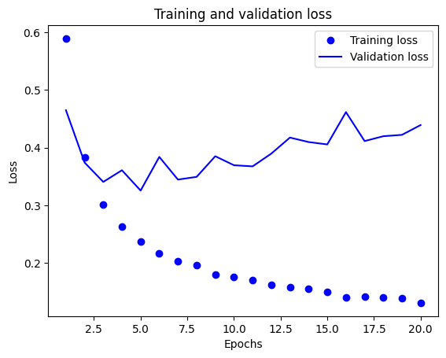

```python
loss = history.history['loss']
val_loss = history.history['val_loss']

epochs = range(1, len(loss) + 1)

# "bo" is for "blue dot"
plt.plot(epochs, loss, 'bo', label='Training loss')
# b is for "solid blue line"
plt.plot(epochs, val_loss, 'b', label='Validation loss')
plt.title('Training and validation loss')
plt.xlabel('Epochs')
plt.ylabel('Loss')
plt.legend()

plt.show()
```

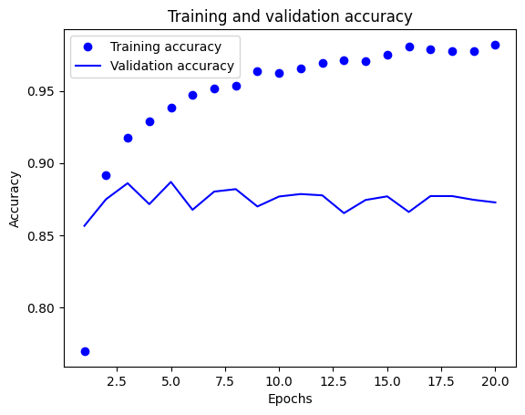

```python
acc = history.history['accuracy']
val_acc = history.history['val_accuracy']

epochs = range(1, len(loss) + 1)

# "bo" is for "blue dot"
plt.plot(epochs, acc, 'bo', label='Training accuracy')
# b is for "solid blue line"
plt.plot(epochs, val_acc, 'b', label='Validation accuracy')
plt.title('Training and validation accuracy')
plt.xlabel('Epochs')
plt.ylabel('Accuracy')
plt.legend()

plt.show()
```

```python
results
```

```
[0.46195879578590393, 0.8638399839401245]
```

```python
model.predict(x_test)
```

```
782/782 ━━━━━━━━━━━━━━━━━━━━ 0s 288us/step
```

```
array([[0.11396831],
       [0.9999873 ],
       [0.87424004],
       ...,
       [0.02416535],
       [0.06046671],
       [0.9410946 ]], shape=(25000, 1), dtype=float32)
```

The applied L2 regularization does not affect the overfiting.

Although the model in problem 1 and our current experiment are overfitting, The accuracy in problem 1 (88%) is slightly better than our current experiment (86%)

#### Experiment 3: Add L1_L2(0.01, 0.01) Regularization to the Dense Layers

```python
model = models.Sequential()
model.add(Input(shape=(10000,))),
model.add(layers.Dense(16, activation='relu', kernel_regularizer=regularizers.l1_l2(0.01,0.01)))
model.add(layers.Dense(16, activation='relu', kernel_regularizer=regularizers.l1_l2(0.01,0.01)))
model.add(layers.Dense(1, activation='sigmoid'))

model.compile(optimizer='rmsprop',
              loss='binary_crossentropy',
              metrics=['accuracy'])

history = model.fit(partial_x_train,
                    partial_y_train,
                    epochs=20,
                    batch_size=512,
                    validation_data=(x_val, y_val))
results = model.evaluate(x_test, y_test)
```

```
30/30 ━━━━━━━━━━━━━━━━━━━━ 1s 9ms/step - accuracy: 0.5581 - loss: 5.0958 - val_accuracy: 0.5128 - val_loss: 2.0659
30/30 ━━━━━━━━━━━━━━━━━━━━ 0s 5ms/step - accuracy: 0.6130 - loss: 2.0202 - val_accuracy: 0.6496 - val_loss: 1.9550
30/30 ━━━━━━━━━━━━━━━━━━━━ 0s 5ms/step - accuracy: 0.6570 - loss: 1.9265 - val_accuracy: 0.6475 - val_loss: 1.8730
30/30 ━━━━━━━━━━━━━━━━━━━━ 0s 5ms/step - accuracy: 0.6701 - loss: 1.8475 - val_accuracy: 0.6907 - val_loss: 1.8012
30/30 ━━━━━━━━━━━━━━━━━━━━ 0s 5ms/step - accuracy: 0.6827 - loss: 1.7783 - val_accuracy: 0.6369 - val_loss: 1.7399
30/30 ━━━━━━━━━━━━━━━━━━━━ 0s 5ms/step - accuracy: 0.6818 - loss: 1.7188 - val_accuracy: 0.6669 - val_loss: 1.6837
30/30 ━━━━━━━━━━━━━━━━━━━━ 0s 5ms/step - accuracy: 0.6893 - loss: 1.6653 - val_accuracy: 0.7051 - val_loss: 1.6326
30/30 ━━━━━━━━━━━━━━━━━━━━ 0s 5ms/step - accuracy: 0.7026 - loss: 1.6173 - val_accuracy: 0.7157 - val_loss: 1.5897
30/30 ━━━━━━━━━━━━━━━━━━━━ 0s 5ms/step - accuracy: 0.7160 - loss: 1.5754 - val_accuracy: 0.7293 - val_loss: 1.5511
30/30 ━━━━━━━━━━━━━━━━━━━━ 0s 5ms/step - accuracy: 0.7302 - loss: 1.5394 - val_accuracy: 0.7224 - val_loss: 1.5223
30/30 ━━━━━━━━━━━━━━━━━━━━ 0s 5ms/step - accuracy: 0.7444 - loss: 1.5095 - val_accuracy: 0.7480 - val_loss: 1.5016
30/30 ━━━━━━━━━━━━━━━━━━━━ 0s 5ms/step - accuracy: 0.7567 - loss: 1.4848 - val_accuracy: 0.7671 - val_loss: 1.4758
30/30 ━━━━━━━━━━━━━━━━━━━━ 0s 5ms/step - accuracy: 0.7658 - loss: 1.4641 - val_accuracy: 0.7671 - val_loss: 1.4603
30/30 ━━━━━━━━━━━━━━━━━━━━ 0s 5ms/step - accuracy: 0.7727 - loss: 1.4490 - val_accuracy: 0.7816 - val_loss: 1.4426
30/30 ━━━━━━━━━━━━━━━━━━━━ 0s 5ms/step - accuracy: 0.7801 - loss: 1.4372 - val_accuracy: 0.7790 - val_loss: 1.4399
30/30 ━━━━━━━━━━━━━━━━━━━━ 0s 5ms/step - accuracy: 0.7873 - loss: 1.4279 - val_accuracy: 0.7866 - val_loss: 1.4281
30/30 ━━━━━━━━━━━━━━━━━━━━ 0s 5ms/step - accuracy: 0.7909 - loss: 1.4219 - val_accuracy: 0.7916 - val_loss: 1.4241
30/30 ━━━━━━━━━━━━━━━━━━━━ 0s 5ms/step - accuracy: 0.7998 - loss: 1.4124 - val_accuracy: 0.8016 - val_loss: 1.4140
30/30 ━━━━━━━━━━━━━━━━━━━━ 0s 5ms/step - accuracy: 0.8050 - loss: 1.4051 - val_accuracy: 0.8084 - val_loss: 1.4022
30/30 ━━━━━━━━━━━━━━━━━━━━ 0s 5ms/step - accuracy: 0.8072 - loss: 1.3988 - val_accuracy: 0.8108 - val_loss: 1.4017
782/782 ━━━━━━━━━━━━━━━━━━━━ 0s 392us/step - accuracy: 0.8078 - loss: 1.4030
```

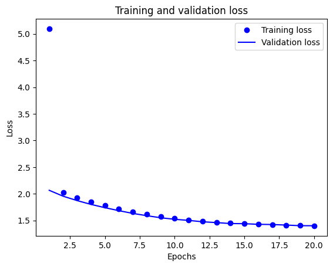

```python
loss = history.history['loss']
val_loss = history.history['val_loss']

epochs = range(1, len(loss) + 1)

# "bo" is for "blue dot"
plt.plot(epochs, loss, 'bo', label='Training loss')
# b is for "solid blue line"
plt.plot(epochs, val_loss, 'b', label='Validation loss')
plt.title('Training and validation loss')
plt.xlabel('Epochs')
plt.ylabel('Loss')
plt.legend()

plt.show()
```

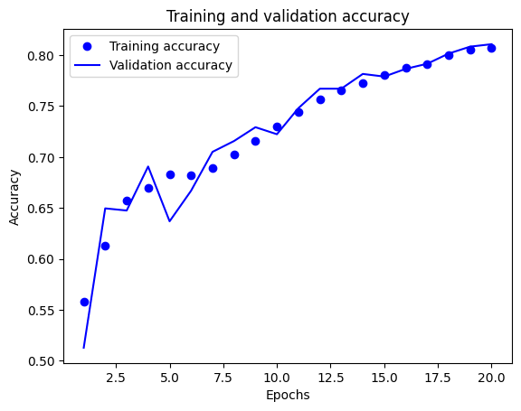

```python
acc = history.history['accuracy']
val_acc = history.history['val_accuracy']

epochs = range(1, len(loss) + 1)

# "bo" is for "blue dot"
plt.plot(epochs, acc, 'bo', label='Training accuracy')
# b is for "solid blue line"
plt.plot(epochs, val_acc, 'b', label='Validation accuracy')
plt.title('Training and validation accuracy')
plt.xlabel('Epochs')
plt.ylabel('Accuracy')
plt.legend()

plt.show()
```

```python
results
```

```
[1.402972936630249, 0.8078399896621704]
```

```python
model.predict(x_test)
```

```
782/782 ━━━━━━━━━━━━━━━━━━━━ 0s 289us/step
```

```
array([[0.45159933],
       [0.66728747],
       [0.70443946],
       ...,
       [0.24866542],
       [0.14178725],
       [0.35976025]], shape=(25000, 1), dtype=float32)
```

The applied L1_L2 regularization affected the overfitting by reducing it.

Although the model in problem 1 is overfitting, The accuracy (88%) is better than our current experiment (81%)

#### Experiment 4: Add L1_L2(0.005, 0.005) Regularization to the Dense Layers

```python
model = models.Sequential()
model.add(Input(shape=(10000,))),
model.add(layers.Dense(16, activation='relu', kernel_regularizer=regularizers.l1_l2(0.005,0.005)))
model.add(layers.Dense(16, activation='relu', kernel_regularizer=regularizers.l1_l2(0.005,0.005)))
model.add(layers.Dense(1, activation='sigmoid'))

model.compile(optimizer='rmsprop',
              loss='binary_crossentropy',
              metrics=['accuracy'])

history = model.fit(partial_x_train,
                    partial_y_train,
                    epochs=20,
                    batch_size=512,
                    validation_data=(x_val, y_val))
results = model.evaluate(x_test, y_test)
```

```
30/30 ━━━━━━━━━━━━━━━━━━━━ 1s 9ms/step - accuracy: 0.6457 - loss: 2.9150 - val_accuracy: 0.7665 - val_loss: 1.3789
30/30 ━━━━━━━━━━━━━━━━━━━━ 0s 5ms/step - accuracy: 0.7592 - loss: 1.3380 - val_accuracy: 0.7116 - val_loss: 1.3152
30/30 ━━━━━━━━━━━━━━━━━━━━ 0s 5ms/step - accuracy: 0.7811 - loss: 1.2748 - val_accuracy: 0.7350 - val_loss: 1.2785
30/30 ━━━━━━━━━━━━━━━━━━━━ 0s 5ms/step - accuracy: 0.7999 - loss: 1.2180 - val_accuracy: 0.7804 - val_loss: 1.2136
30/30 ━━━━━━━━━━━━━━━━━━━━ 0s 5ms/step - accuracy: 0.8128 - loss: 1.1668 - val_accuracy: 0.8101 - val_loss: 1.1526
30/30 ━━━━━━━━━━━━━━━━━━━━ 0s 5ms/step - accuracy: 0.8211 - loss: 1.1215 - val_accuracy: 0.8160 - val_loss: 1.1126
30/30 ━━━━━━━━━━━━━━━━━━━━ 0s 5ms/step - accuracy: 0.8240 - loss: 1.0831 - val_accuracy: 0.8300 - val_loss: 1.0745
30/30 ━━━━━━━━━━━━━━━━━━━━ 0s 5ms/step - accuracy: 0.8285 - loss: 1.0506 - val_accuracy: 0.8336 - val_loss: 1.0430
30/30 ━━━━━━━━━━━━━━━━━━━━ 0s 5ms/step - accuracy: 0.8367 - loss: 1.0199 - val_accuracy: 0.8360 - val_loss: 1.0164
30/30 ━━━━━━━━━━━━━━━━━━━━ 0s 5ms/step - accuracy: 0.8383 - loss: 0.9986 - val_accuracy: 0.8376 - val_loss: 0.9937
30/30 ━━━━━━━━━━━━━━━━━━━━ 0s 5ms/step - accuracy: 0.8449 - loss: 0.9761 - val_accuracy: 0.8339 - val_loss: 0.9869
30/30 ━━━━━━━━━━━━━━━━━━━━ 0s 5ms/step - accuracy: 0.8481 - loss: 0.9611 - val_accuracy: 0.8420 - val_loss: 0.9633
30/30 ━━━━━━━━━━━━━━━━━━━━ 0s 5ms/step - accuracy: 0.8459 - loss: 0.9508 - val_accuracy: 0.8422 - val_loss: 0.9580
30/30 ━━━━━━━━━━━━━━━━━━━━ 0s 5ms/step - accuracy: 0.8469 - loss: 0.9395 - val_accuracy: 0.8459 - val_loss: 0.9448
30/30 ━━━━━━━━━━━━━━━━━━━━ 0s 5ms/step - accuracy: 0.8518 - loss: 0.9322 - val_accuracy: 0.8148 - val_loss: 0.9885
30/30 ━━━━━━━━━━━━━━━━━━━━ 0s 5ms/step - accuracy: 0.8527 - loss: 0.9278 - val_accuracy: 0.8414 - val_loss: 0.9552
30/30 ━━━━━━━━━━━━━━━━━━━━ 0s 5ms/step - accuracy: 0.8567 - loss: 0.9222 - val_accuracy: 0.8397 - val_loss: 0.9458
30/30 ━━━━━━━━━━━━━━━━━━━━ 0s 5ms/step - accuracy: 0.8571 - loss: 0.9153 - val_accuracy: 0.8471 - val_loss: 0.9344
30/30 ━━━━━━━━━━━━━━━━━━━━ 0s 5ms/step - accuracy: 0.8588 - loss: 0.9128 - val_accuracy: 0.8514 - val_loss: 0.9274
30/30 ━━━━━━━━━━━━━━━━━━━━ 0s 5ms/step - accuracy: 0.8586 - loss: 0.9070 - val_accuracy: 0.8469 - val_loss: 0.9342
782/782 ━━━━━━━━━━━━━━━━━━━━ 0s 427us/step - accuracy: 0.8452 - loss: 0.9372
```

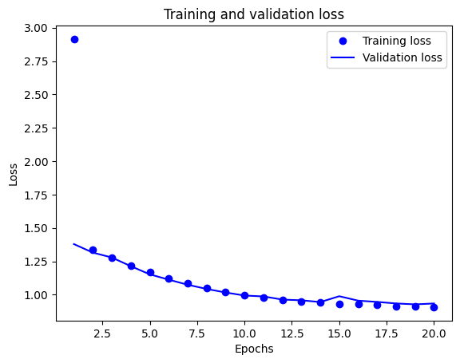

```python
loss = history.history['loss']
val_loss = history.history['val_loss']

epochs = range(1, len(loss) + 1)

# "bo" is for "blue dot"
plt.plot(epochs, loss, 'bo', label='Training loss')
# b is for "solid blue line"
plt.plot(epochs, val_loss, 'b', label='Validation loss')
plt.title('Training and validation loss')
plt.xlabel('Epochs')
plt.ylabel('Loss')
plt.legend()

plt.show()
```

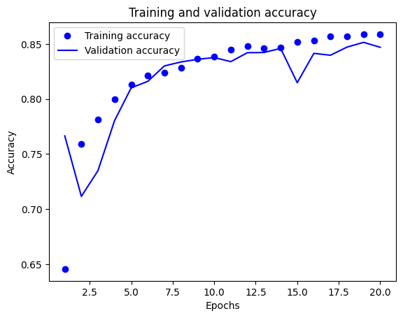

```python
acc = history.history['accuracy']
val_acc = history.history['val_accuracy']

epochs = range(1, len(loss) + 1)

# "bo" is for "blue dot"
plt.plot(epochs, acc, 'bo', label='Training accuracy')
# b is for "solid blue line"
plt.plot(epochs, val_acc, 'b', label='Validation accuracy')
plt.title('Training and validation accuracy')
plt.xlabel('Epochs')
plt.ylabel('Accuracy')
plt.legend()

plt.show()
```

```python
results
```

```
[0.9371799230575562, 0.8452000021934509]
```

```python
model.predict(x_test)
```

```
782/782 ━━━━━━━━━━━━━━━━━━━━ 0s 289us/step
```

```
array([[0.294942  ],
       [0.931171  ],
       [0.6286373 ],
       ...,
       [0.13571168],
       [0.06692   ],
       [0.25834832]], shape=(25000, 1), dtype=float32)
```

The applied L1_L2 regularization affected the overfitting by reducing it.

# Problem 3: Dropout

Let us do some more tests with Classifying-movie- reviews.ipynb notebook. This time, to fight overfitting, instead of regularization add a Dropout layer after the first and the second hidden Dense layer. (You do not apply dropout, usually, to the Input layer and to the output layer.) Run tests with Dropout layers which pass 20% of signal from the preceding Dense layers and in the second experiment with the Dropout layers that pass 10% of the signal. Compare accuracy and loss function plots with those you generated in Problem 1 and 2. Also, make comparison with the results for the Dropout layers with 50% reported in the notes. Report whether applied Dropout layers affected the overfitting. If yes, in what way.  
(20%)

```python
model = models.Sequential()
model.add(Input(shape=(10000,))),
model.add(layers.Dense(16, activation='relu'))
model.add(layers.Dropout(0.2))
model.add(layers.Dense(16, activation='relu'))
model.add(layers.Dropout(0.2))
model.add(layers.Dense(1, activation='sigmoid'))

model.compile(optimizer='rmsprop',
              loss='binary_crossentropy',
              metrics=['accuracy'])

history = model.fit(partial_x_train,
                    partial_y_train,
                    epochs=20,
                    batch_size=512,
                    validation_data=(x_val, y_val))
results = model.evaluate(x_test, y_test)
```

```
30/30 ━━━━━━━━━━━━━━━━━━━━ 1s 9ms/step - accuracy: 0.7359 - loss: 0.5622 - val_accuracy: 0.8601 - val_loss: 0.4275
30/30 ━━━━━━━━━━━━━━━━━━━━ 0s 5ms/step - accuracy: 0.8537 - loss: 0.3924 - val_accuracy: 0.8553 - val_loss: 0.3634
30/30 ━━━━━━━━━━━━━━━━━━━━ 0s 5ms/step - accuracy: 0.8939 - loss: 0.3022 - val_accuracy: 0.8818 - val_loss: 0.3021
30/30 ━━━━━━━━━━━━━━━━━━━━ 0s 5ms/step - accuracy: 0.9147 - loss: 0.2476 - val_accuracy: 0.8835 - val_loss: 0.2871
30/30 ━━━━━━━━━━━━━━━━━━━━ 0s 5ms/step - accuracy: 0.9319 - loss: 0.2054 - val_accuracy: 0.8863 - val_loss: 0.2750
30/30 ━━━━━━━━━━━━━━━━━━━━ 0s 5ms/step - accuracy: 0.9445 - loss: 0.1719 - val_accuracy: 0.8864 - val_loss: 0.2846
30/30 ━━━━━━━━━━━━━━━━━━━━ 0s 8ms/step - accuracy: 0.9540 - loss: 0.1443 - val_accuracy: 0.8848 - val_loss: 0.2983
30/30 ━━━━━━━━━━━━━━━━━━━━ 0s 5ms/step - accuracy: 0.9597 - loss: 0.1240 - val_accuracy: 0.8853 - val_loss: 0.3025
30/30 ━━━━━━━━━━━━━━━━━━━━ 0s 6ms/step - accuracy: 0.9698 - loss: 0.0994 - val_accuracy: 0.8835 - val_loss: 0.3234
30/30 ━━━━━━━━━━━━━━━━━━━━ 0s 7ms/step - accuracy: 0.9743 - loss: 0.0846 - val_accuracy: 0.8839 - val_loss: 0.3411
30/30 ━━━━━━━━━━━━━━━━━━━━ 0s 5ms/step - accuracy: 0.9796 - loss: 0.0712 - val_accuracy: 0.8808 - val_loss: 0.3686
30/30 ━━━━━━━━━━━━━━━━━━━━ 0s 7ms/step - accuracy: 0.9851 - loss: 0.0566 - val_accuracy: 0.8799 - val_loss: 0.4016
30/30 ━━━━━━━━━━━━━━━━━━━━ 0s 5ms/step - accuracy: 0.9859 - loss: 0.0489 - val_accuracy: 0.8806 - val_loss: 0.4240
30/30 ━━━━━━━━━━━━━━━━━━━━ 0s 7ms/step - accuracy: 0.9889 - loss: 0.0412 - val_accuracy: 0.8728 - val_loss: 0.4547
30/30 ━━━━━━━━━━━━━━━━━━━━ 0s 7ms/step - accuracy: 0.9926 - loss: 0.0313 - val_accuracy: 0.8715 - val_loss: 0.5083
30/30 ━━━━━━━━━━━━━━━━━━━━ 0s 5ms/step - accuracy: 0.9929 - loss: 0.0286 - val_accuracy: 0.8789 - val_loss: 0.5004
30/30 ━━━━━━━━━━━━━━━━━━━━ 0s 6ms/step - accuracy: 0.9937 - loss: 0.0265 - val_accuracy: 0.8772 - val_loss: 0.5318
30/30 ━━━━━━━━━━━━━━━━━━━━ 0s 5ms/step - accuracy: 0.9968 - loss: 0.0172 - val_accuracy: 0.8766 - val_loss: 0.5506
30/30 ━━━━━━━━━━━━━━━━━━━━ 0s 5ms/step - accuracy: 0.9973 - loss: 0.0159 - val_accuracy: 0.8765 - val_loss: 0.6188
30/30 ━━━━━━━━━━━━━━━━━━━━ 0s 5ms/step - accuracy: 0.9964 - loss: 0.0162 - val_accuracy: 0.8776 - val_loss: 0.6244
782/782 ━━━━━━━━━━━━━━━━━━━━ 0s 379us/step - accuracy: 0.8652 - loss: 0.6935
```

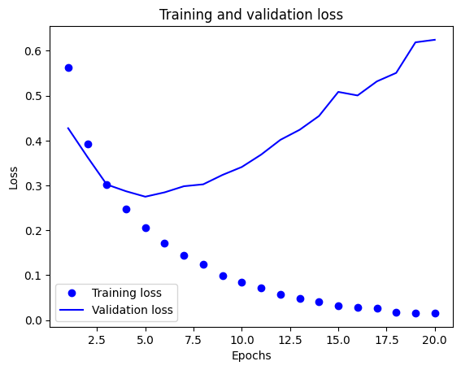

```python
loss = history.history['loss']
val_loss = history.history['val_loss']

epochs = range(1, len(loss) + 1)

# "bo" is for "blue dot"
plt.plot(epochs, loss, 'bo', label='Training loss')
# b is for "solid blue line"
plt.plot(epochs, val_loss, 'b', label='Validation loss')
plt.title('Training and validation loss')
plt.xlabel('Epochs')
plt.ylabel('Loss')
plt.legend()

plt.show()
```

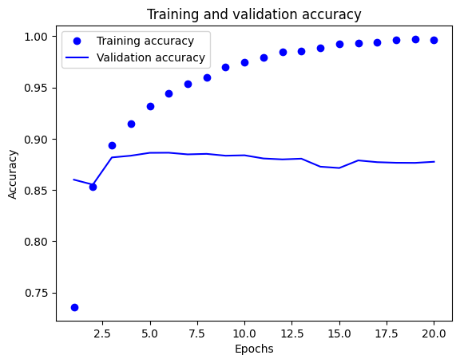

```python
acc = history.history['accuracy']
val_acc = history.history['val_accuracy']

epochs = range(1, len(loss) + 1)

# "bo" is for "blue dot"
plt.plot(epochs, acc, 'bo', label='Training accuracy')
# b is for "solid blue line"
plt.plot(epochs, val_acc, 'b', label='Validation accuracy')
plt.title('Training and validation accuracy')
plt.xlabel('Epochs')
plt.ylabel('Accuracy')
plt.legend()

plt.show()
```

```python
results
```

```
[0.693480908870697, 0.8651999831199646]
```

```python
model.predict(x_test)
```

```
782/782 ━━━━━━━━━━━━━━━━━━━━ 0s 333us/step
```

```
array([[4.0885708e-03],
       [9.9999982e-01],
       [9.9288279e-01],
       ...,
       [2.9915306e-04],
       [6.1725272e-04],
       [8.7024689e-01]], shape=(25000, 1), dtype=float32)
```

The introduction of the dropout layers did not reduce the overfitting.

Although the model in problem 1 and our current experiment are overfitting, The accuracy in problem 1 (88%) is slightly better than our current experiment (87%)

```python
model = models.Sequential()
model.add(Input(shape=(10000,))),
model.add(layers.Dense(16, activation='relu'))
model.add(layers.Dropout(0.1))
model.add(layers.Dense(16, activation='relu'))
model.add(layers.Dropout(0.1))
model.add(layers.Dense(1, activation='sigmoid'))

model.compile(optimizer='rmsprop',
              loss='binary_crossentropy',
              metrics=['accuracy'])

history = model.fit(partial_x_train,
                    partial_y_train,
                    epochs=20,
                    batch_size=512,
                    validation_data=(x_val, y_val))
results = model.evaluate(x_test, y_test)
```

```
30/30 ━━━━━━━━━━━━━━━━━━━━ 1s 11ms/step - accuracy: 0.7239 - loss: 0.5756 - val_accuracy: 0.8605 - val_loss: 0.4396
30/30 ━━━━━━━━━━━━━━━━━━━━ 0s 5ms/step - accuracy: 0.8622 - loss: 0.3841 - val_accuracy: 0.8610 - val_loss: 0.3556
30/30 ━━━━━━━━━━━━━━━━━━━━ 0s 5ms/step - accuracy: 0.8977 - loss: 0.2902 - val_accuracy: 0.8862 - val_loss: 0.2925
30/30 ━━━━━━━━━━━━━━━━━━━━ 0s 5ms/step - accuracy: 0.9186 - loss: 0.2335 - val_accuracy: 0.8910 - val_loss: 0.2757
30/30 ━━━━━━━━━━━━━━━━━━━━ 0s 6ms/step - accuracy: 0.9333 - loss: 0.1953 - val_accuracy: 0.8896 - val_loss: 0.2743
30/30 ━━━━━━━━━━━━━━━━━━━━ 0s 5ms/step - accuracy: 0.9461 - loss: 0.1619 - val_accuracy: 0.8793 - val_loss: 0.3106
30/30 ━━━━━━━━━━━━━━━━━━━━ 0s 5ms/step - accuracy: 0.9548 - loss: 0.1385 - val_accuracy: 0.8820 - val_loss: 0.3096
30/30 ━━━━━━━━━━━━━━━━━━━━ 0s 5ms/step - accuracy: 0.9626 - loss: 0.1152 - val_accuracy: 0.8843 - val_loss: 0.3037
30/30 ━━━━━━━━━━━━━━━━━━━━ 0s 5ms/step - accuracy: 0.9693 - loss: 0.0989 - val_accuracy: 0.8802 - val_loss: 0.3239
30/30 ━━━━━━━━━━━━━━━━━━━━ 0s 5ms/step - accuracy: 0.9760 - loss: 0.0810 - val_accuracy: 0.8784 - val_loss: 0.3533
30/30 ━━━━━━━━━━━━━━━━━━━━ 0s 7ms/step - accuracy: 0.9804 - loss: 0.0691 - val_accuracy: 0.8781 - val_loss: 0.3694
30/30 ━━━━━━━━━━━━━━━━━━━━ 0s 5ms/step - accuracy: 0.9849 - loss: 0.0567 - val_accuracy: 0.8815 - val_loss: 0.3843
30/30 ━━━━━━━━━━━━━━━━━━━━ 0s 5ms/step - accuracy: 0.9862 - loss: 0.0489 - val_accuracy: 0.8700 - val_loss: 0.4380
30/30 ━━━━━━━━━━━━━━━━━━━━ 0s 5ms/step - accuracy: 0.9909 - loss: 0.0375 - val_accuracy: 0.8741 - val_loss: 0.4536
30/30 ━━━━━━━━━━━━━━━━━━━━ 0s 5ms/step - accuracy: 0.9916 - loss: 0.0333 - val_accuracy: 0.8758 - val_loss: 0.4661
30/30 ━━━━━━━━━━━━━━━━━━━━ 0s 5ms/step - accuracy: 0.9926 - loss: 0.0279 - val_accuracy: 0.8779 - val_loss: 0.4845
30/30 ━━━━━━━━━━━━━━━━━━━━ 0s 5ms/step - accuracy: 0.9965 - loss: 0.0196 - val_accuracy: 0.8756 - val_loss: 0.5192
30/30 ━━━━━━━━━━━━━━━━━━━━ 0s 5ms/step - accuracy: 0.9949 - loss: 0.0215 - val_accuracy: 0.8755 - val_loss: 0.5453
30/30 ━━━━━━━━━━━━━━━━━━━━ 0s 5ms/step - accuracy: 0.9980 - loss: 0.0127 - val_accuracy: 0.8769 - val_loss: 0.5760
30/30 ━━━━━━━━━━━━━━━━━━━━ 0s 5ms/step - accuracy: 0.9974 - loss: 0.0133 - val_accuracy: 0.8759 - val_loss: 0.5960
782/782 ━━━━━━━━━━━━━━━━━━━━ 0s 353us/step - accuracy: 0.8626 - loss: 0.6467
```

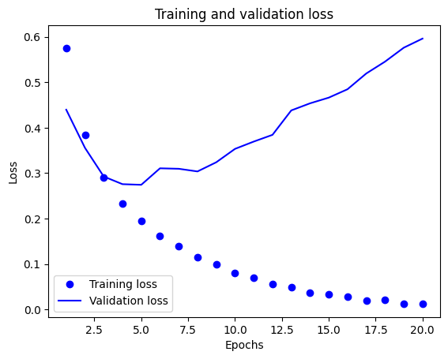

```python
loss = history.history['loss']
val_loss = history.history['val_loss']

epochs = range(1, len(loss) + 1)

# "bo" is for "blue dot"
plt.plot(epochs, loss, 'bo', label='Training loss')
# b is for "solid blue line"
plt.plot(epochs, val_loss, 'b', label='Validation loss')
plt.title('Training and validation loss')
plt.xlabel('Epochs')
plt.ylabel('Loss')
plt.legend()

plt.show()
```

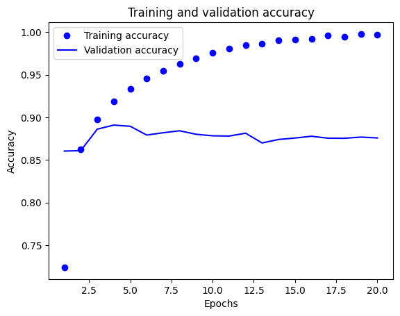

```python
acc = history.history['accuracy']
val_acc = history.history['val_accuracy']

epochs = range(1, len(loss) + 1)

# "bo" is for "blue dot"
plt.plot(epochs, acc, 'bo', label='Training accuracy')
# b is for "solid blue line"
plt.plot(epochs, val_acc, 'b', label='Validation accuracy')
plt.title('Training and validation accuracy')
plt.xlabel('Epochs')
plt.ylabel('Accuracy')
plt.legend()

plt.show()
```

```python
results
```

```
[0.6466629505157471, 0.8626000285148621]
```

```python
model.predict(x_test)
```

```
782/782 ━━━━━━━━━━━━━━━━━━━━ 0s 323us/step
```

```
array([[0.01276388],
       [0.9999998 ],
       [0.9740204 ],
       ...,
       [0.0017334 ],
       [0.00639224],
       [0.9505599 ]], shape=(25000, 1), dtype=float32)
```

The introduction of the dropout layers did not reduce the overfitting.

Although the model in problem 1 and our current experiment are overfitting, The accuracy in problem 1 (88%) is slightly better than our current experiment (86%)

Experiment 3: Dropout Rate of 50% Pass

```python
model = models.Sequential()
model.add(Input(shape=(10000,))),
model.add(layers.Dense(16, activation='relu'))
model.add(layers.Dropout(0.5))
model.add(layers.Dense(16, activation='relu'))
model.add(layers.Dropout(0.5))
model.add(layers.Dense(1, activation='sigmoid'))

model.compile(optimizer='rmsprop',
              loss='binary_crossentropy',
              metrics=['accuracy'])

history = model.fit(partial_x_train,
                    partial_y_train,
                    epochs=20,
                    batch_size=512,
                    validation_data=(x_val, y_val))
results = model.evaluate(x_test, y_test)
```

```
30/30 ━━━━━━━━━━━━━━━━━━━━ 1s 14ms/step - accuracy: 0.6205 - loss: 0.6447 - val_accuracy: 0.8343 - val_loss: 0.5577
30/30 ━━━━━━━━━━━━━━━━━━━━ 0s 6ms/step - accuracy: 0.7629 - loss: 0.5209 - val_accuracy: 0.8723 - val_loss: 0.4274
30/30 ━━━━━━━━━━━━━━━━━━━━ 0s 6ms/step - accuracy: 0.8271 - loss: 0.4323 - val_accuracy: 0.8799 - val_loss: 0.3547
30/30 ━━━━━━━━━━━━━━━━━━━━ 0s 5ms/step - accuracy: 0.8637 - loss: 0.3684 - val_accuracy: 0.8844 - val_loss: 0.3096
30/30 ━━━━━━━━━━━━━━━━━━━━ 0s 6ms/step - accuracy: 0.8945 - loss: 0.3134 - val_accuracy: 0.8801 - val_loss: 0.3079
30/30 ━━━━━━━━━━━━━━━━━━━━ 0s 6ms/step - accuracy: 0.9100 - loss: 0.2750 - val_accuracy: 0.8913 - val_loss: 0.2793
30/30 ━━━━━━━━━━━━━━━━━━━━ 0s 5ms/step - accuracy: 0.9215 - loss: 0.2437 - val_accuracy: 0.8906 - val_loss: 0.2777
30/30 ━━━━━━━━━━━━━━━━━━━━ 0s 6ms/step - accuracy: 0.9320 - loss: 0.2172 - val_accuracy: 0.8884 - val_loss: 0.2793
30/30 ━━━━━━━━━━━━━━━━━━━━ 0s 7ms/step - accuracy: 0.9409 - loss: 0.1891 - val_accuracy: 0.8888 - val_loss: 0.2970
30/30 ━━━━━━━━━━━━━━━━━━━━ 0s 5ms/step - accuracy: 0.9488 - loss: 0.1721 - val_accuracy: 0.8854 - val_loss: 0.3342
30/30 ━━━━━━━━━━━━━━━━━━━━ 0s 6ms/step - accuracy: 0.9543 - loss: 0.1554 - val_accuracy: 0.8860 - val_loss: 0.3313
30/30 ━━━━━━━━━━━━━━━━━━━━ 0s 6ms/step - accuracy: 0.9565 - loss: 0.1394 - val_accuracy: 0.8826 - val_loss: 0.3383
30/30 ━━━━━━━━━━━━━━━━━━━━ 0s 6ms/step - accuracy: 0.9623 - loss: 0.1260 - val_accuracy: 0.8842 - val_loss: 0.3707
30/30 ━━━━━━━━━━━━━━━━━━━━ 0s 6ms/step - accuracy: 0.9657 - loss: 0.1126 - val_accuracy: 0.8831 - val_loss: 0.3915
30/30 ━━━━━━━━━━━━━━━━━━━━ 0s 6ms/step - accuracy: 0.9681 - loss: 0.1081 - val_accuracy: 0.8843 - val_loss: 0.3979
30/30 ━━━━━━━━━━━━━━━━━━━━ 0s 6ms/step - accuracy: 0.9701 - loss: 0.0980 - val_accuracy: 0.8829 - val_loss: 0.4060
30/30 ━━━━━━━━━━━━━━━━━━━━ 0s 6ms/step - accuracy: 0.9733 - loss: 0.0895 - val_accuracy: 0.8802 - val_loss: 0.4610
30/30 ━━━━━━━━━━━━━━━━━━━━ 0s 6ms/step - accuracy: 0.9749 - loss: 0.0832 - val_accuracy: 0.8821 - val_loss: 0.4637
30/30 ━━━━━━━━━━━━━━━━━━━━ 0s 5ms/step - accuracy: 0.9768 - loss: 0.0790 - val_accuracy: 0.8819 - val_loss: 0.5146
30/30 ━━━━━━━━━━━━━━━━━━━━ 0s 5ms/step - accuracy: 0.9769 - loss: 0.0774 - val_accuracy: 0.8812 - val_loss: 0.5258
782/782 ━━━━━━━━━━━━━━━━━━━━ 0s 404us/step - accuracy: 0.8733 - loss: 0.5628
```

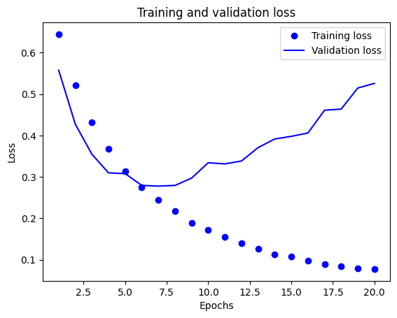

```python
loss = history.history['loss']
val_loss = history.history['val_loss']

epochs = range(1, len(loss) + 1)

# "bo" is for "blue dot"
plt.plot(epochs, loss, 'bo', label='Training loss')
# b is for "solid blue line"
plt.plot(epochs, val_loss, 'b', label='Validation loss')
plt.title('Training and validation loss')
plt.xlabel('Epochs')
plt.ylabel('Loss')
plt.legend()

plt.show()
```

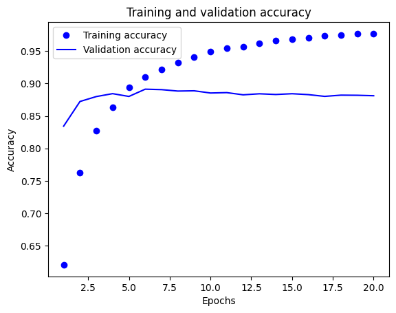

```python
acc = history.history['accuracy']
val_acc = history.history['val_accuracy']

epochs = range(1, len(loss) + 1)

# "bo" is for "blue dot"
plt.plot(epochs, acc, 'bo', label='Training accuracy')
# b is for "solid blue line"
plt.plot(epochs, val_acc, 'b', label='Validation accuracy')
plt.title('Training and validation accuracy')
plt.xlabel('Epochs')
plt.ylabel('Accuracy')
plt.legend()

plt.show()
```

```python
results
```

```
[0.562802255153656, 0.8732799887657166]
```

```python
model.predict(x_test)
```

```
782/782 ━━━━━━━━━━━━━━━━━━━━ 0s 379us/step
```

```
array([[5.2686185e-03],
       [9.9999815e-01],
       [9.9963939e-01],
       ...,
       [2.8975116e-04],
       [3.8914711e-04],
       [8.1897593e-01]], shape=(25000, 1), dtype=float32)
```

The introduction of the dropout layers did not reduce the overfitting.

Although the model in problem 1 and our current experiment are overfitting, The accuracy in problem 1 (88%) is slightly better than our current experiment (87%)